# **March Madness Student Reading Log Analytics | Exploratory Data Analysis & Derived Insights**

## **S. Taylor**

**Objective:**

To analyze reading log performance across grades K–5, identify top performers, highlight students needing support, and visualize class trends for school administrators and teachers.

- Identify top performers
- Students needing support
- Progression Trends
- Class Performance Distribution & Outliers

**Data Source:**

- CSV of student reading log points (`MM.csv`)
- Columns: `Grade`, `Teacher`, `Student`, `RL1`, `RL2`, `RL3`, `RL4`, `TotalPoints`

**Tools & Libraries:**

- Python: pandas, seaborn, matplotlib
- SQL (SQLite) for aggregation
- Jupyter Notebook for analysis and visualization

### Setup

```python
%%capture
# Install & import
!pip install pandas seaborn matplotlib
import pandas as pd
import seaborn as sns
import matplotlib.pyplot as plt
from IPython.display import display
import sqlite3
#------------------------------
# Database connection
con = sqlite3.connect("MM.db")
cur = con.cursor()
#colors = ['#FF8C00', '', '', '', '']
#----------------------------------------------------------------
# SQL magic
%load_ext sql
%sql sqlite:///MM.db
```

### Load & Prepare Data

```python
%%capture
# Load CSV & fill missing data with 0 time
MMRC_df = pd.read_csv("MM.csv").fillna(0)
# Shorten names to keep anonymized
MMRC_df['Student'] = MMRC_df['Student'].str[:6]
MMRC_df['Teacher'] = MMRC_df['Teacher'].str[:6]

# Save to SQL
MMRC_df.to_sql("MM_DATA", con, if_exists='replace', index=False, method="multi")
```

```python
# Makes K come first
grade_order = ['K', '1', '2', '3', '4', '5']
def set_grade_order(df, grade_col='Grade'):
    df[grade_col] = pd.Categorical(df[grade_col], categories=grade_order, ordered=True)
    return df.sort_values(grade_col)
```

## **Finding Top Performers**

**Objective:** Identify high achievers at different levels — student, class, and teacher — to recognize excellence and set benchmarks for performance.

**Key Takeaways:**

- Recognizing top students, classes, and teachers motivates and rewards excellence.
- Provides benchmarks for comparison and goal setting across grades and classes.
- Can inform resource allocation or targeted support to replicate successful strategies.
- Helps identify patterns of high performance that can be leveraged for broader instructional improvements.

### Top Student Per Class

- Identifies the student with the highest total points in each class.
- Insight: Highlights individual excellence and allows teachers to recognize and reward top performers.
- Table Example: Shows `Grade`, `Teacher`, `Student`, and `TotalPoints`.

```python
top_students_per_class = (
    MMRC_df.sort_values(['Grade','Teacher','TotalPoints'], ascending=[True,True,False])
    .groupby(['Grade','Teacher']).first().reset_index()
)
top_students_per_class = set_grade_order(top_students_per_class)
display(top_students_per_class[['Grade','Teacher','Student','TotalPoints']].style.hide(axis='index'))
```

[output not shown]

### Top Class Per Grade

- Calculates the sum of total points per class and highlights the class with the highest aggregate score per grade.
- Insight: Identifies high-performing classes and encourages sharing of best practices among teachers.
- Table Example: Shows `Grade`, `Teacher`, and `TotalPoints`.

```python
total_points_per_class = MMRC_df.groupby(['Grade','Teacher'])['TotalPoints'].sum().reset_index()
top_class_per_grade = total_points_per_class.loc[total_points_per_class.groupby('Grade')['TotalPoints'].idxmax()]
top_class_per_grade = top_class_per_grade.sort_values(by='TotalPoints', ascending=False)
display(top_class_per_grade.style.hide(axis='index'))
```

| Grade | Teacher | TotalPoints |
| --- | --- | --- |
| 4 | WZ | 19114 |
| 5 | Wright | 18244 |
| 3 | Smith | 11621 |
| 2 | Palaci | 10864 |
| K | Boulwa | 10545 |
| 1 | Miller | 3918 |

Back to top

## **Identifying Students Needing Support**

**Objective:** Highlight students at risk by focusing on those with 0 total points in reading logs, and identify patterns by grade and teacher to inform targeted interventions.

**Key Takeaways:**

- Zero-point students are a clear signal of students needing support.
- Visualization and aggregation by grade and teacher make it easy to prioritize interventions.
- This approach ensures administrators and teachers can take targeted, actionable steps rather than relying on anecdotal observation.

### Student Participation

```python
# Filter out students with 0 points
participating_students = MMRC_df[MMRC_df['TotalPoints'] > 0]

# Count number of participating students per Grade and Teacher
participation_counts = participating_students.groupby(['Grade','Teacher']).size().reset_index(name='NumParticipants')

# Display the table
participation_counts = set_grade_order(participation_counts)
display(participation_counts.style.hide(axis='index'))
```

| Grade | Teacher | NumParticipants |
| --- | --- | --- |
| K | Walter | 13 |
| K | Hilema | 12 |
| K | Boulwa | 12 |
| K | Peters | 10 |
| 1 | Brooks | 11 |
| 1 | Lewis | 10 |
| 1 | Miller | 11 |
| 1 | Payne | 11 |
| 2 | McMull | 14 |
| 2 | Palaci | 16 |
| 2 | Plunke | 17 |
| 2 | Ahrens | 14 |
| 3 | Smith | 14 |
| 3 | Quinta | 11 |
| 3 | Norwar | 11 |
| 3 | Fowell | 14 |
| 3 | Troutm | 12 |
| 4 | Brown | 13 |
| 4 | Koerne | 14 |
| 4 | WZ | 17 |
| 4 | Horgan | 11 |
| 5 | Archam | 18 |
| 5 | Greene | 10 |
| 5 | Wright | 17 |

### Visualize Student Participation By Grade

- Aggregates the total number of students per grade who actively contributed points (TotalPoints > 0).
- Insight: Grades with higher participation indicate strong engagement, while lower counts may signal a need for additional support or encouragement.
- Visual: Bar chart showing `Grade` vs. `Number of Students Participating`.

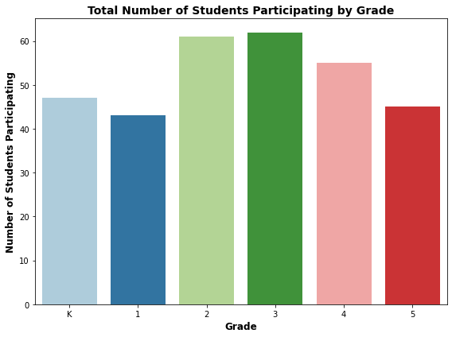

```python
# Filter out students with 0 points
participating_students = MMRC_df[MMRC_df['TotalPoints'] > 0]

# Count total participants per grade
participants_per_grade = participating_students.groupby('Grade').size().reset_index(name='NumParticipants')

participants_per_grade = set_grade_order(participants_per_grade)

# Plot
plt.figure(figsize=(8,6))
sns.barplot(
    data=participants_per_grade,
    x='Grade',
    y='NumParticipants',
    palette=sns.color_palette("Paired")
)
plt.title("Total Number of Students Participating by Grade", fontsize=14, fontweight='bold')
plt.xlabel("Grade", fontsize=12, fontweight='bold')
plt.ylabel("Number of Students Participating", fontsize=12, fontweight='bold')
plt.tight_layout()
plt.show()
```

### Count of Zero-Point Students Per Grade

- Aggregates the number of students with 0 points for each grade.
- Provides a high-level view of which grades have the largest proportion of at-risk students.
- Insight: Grades with more zero-point students may require additional instructional support or monitoring.
- Visual: Table or bar chart showing `Grade` vs. `Count of Students with 0 Points`.

```python
zero_points_per_grade = MMRC_df[MMRC_df['TotalPoints'] == 0]\
                        .groupby('Grade').size().reset_index(name='Students with 0 Points')
zero_points_per_grade = set_grade_order(zero_points_per_grade)
display(zero_points_per_grade.style.hide(axis='index'))
```

| Grade | Students with 0 Points |
| --- | --- |
| K | 4 |
| 1 | 10 |
| 2 | 6 |
| 3 | 12 |
| 4 | 21 |
| 5 | 23 |

### Identify Teachers With Most Zero-Point Students

- Counts zero-point students per teacher/class.
- Highlights which teachers have multiple students at 0 points, identifying classes that may need targeted attention.
- Insight: Helps administrators prioritize support and resources for teachers and classes with higher numbers of at-risk students.
- Visual: Table listing `Grade`, `Teacher`, and `ZeroPointCount`, sorted by highest count.

```python
zero_points_per_teacher = MMRC_df[MMRC_df['TotalPoints'] == 0]\
                          .groupby(['Grade','Teacher']).size().reset_index(name='ZeroPointCount')\
                          .sort_values(by='ZeroPointCount', ascending=False)
display(zero_points_per_teacher.head(10).style.hide(axis='index'))
```

| Grade | Teacher | ZeroPointCount |
| --- | --- | --- |
| 5 | Greene | 12 |
| 4 | Horgan | 7 |
| 5 | Archam | 6 |
| 4 | Brown | 6 |
| 5 | Wright | 5 |
| 4 | Koerne | 5 |
| 2 | McMull | 4 |
| 3 | Norwar | 4 |
| 3 | Quinta | 4 |
| 1 | Lewis | 4 |

### Visualize Zero-Point Students

- Bar charts or other visualizations are used to easily spot trends and outliers.
- Color-coded by grade, these visuals help quickly identify problem areas for intervention.
- Insight: Visual patterns can reveal systemic issues within grades or classes, supporting data-driven decision-making.
- Visual: Bar chart of zero-point students per `Teacher` or per `Grade`, with grades sorted to show K first.

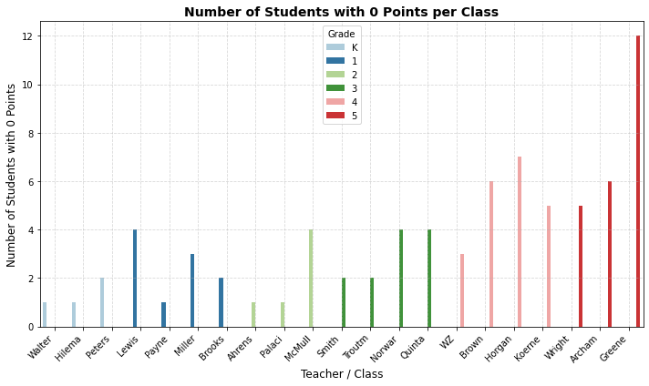

```python
zero_points_per_teacher = set_grade_order(zero_points_per_teacher)

plt.figure(figsize=(10,6))
sns.barplot(data=zero_points_per_teacher, x='Teacher', y='ZeroPointCount', hue='Grade', palette=sns.color_palette("Paired"))
plt.title("Number of Students with 0 Points per Class", fontsize=14, fontweight='bold')
plt.xlabel("Teacher / Class", fontsize=12)
plt.ylabel("Number of Students with 0 Points", fontsize=12)
plt.xticks(rotation=45, ha='right')
plt.grid(True, linestyle='--', alpha=0.5)
plt.tight_layout()
plt.show()
```

Back to top

## **Reading Log Progression Trends (Weeks 1 → 4)**

**Objective:** Track student and class performance across the four reading logs (RL1 → RL4) to identify growth patterns, stagnation, or areas needing attention.

**Key Takeaways:**

- Classes showing steady upward trends indicate consistent improvement in student reading performance.
- Classes with flat or declining trends may require targeted instructional support.
- Comparing classes within a grade allows benchmarking and sharing of best practices among teachers and administrators.
- Patterns across grades can reveal systemic trends in early reading development.

### SQL Template

```python
query_template = """
SELECT
    Teacher AS Class,
    SUM(RL1) AS RL1,
    SUM(RL2) AS RL2,
    SUM(RL3) AS RL3,
    SUM(RL4) AS RL4
FROM MM_DATA
WHERE Grade = '{}'
GROUP BY Teacher
ORDER BY Teacher
"""
```

### Generating & Plotting Per-Grade Trends

- For each grade, total points for each reading log (RL1–RL4) are aggregated per class.
- Data is reshaped from wide to long format to facilitate comparative plotting across classes.
- Line charts are generated per grade to visualize how each class progresses over the four reading logs.

```python
%%capture
grades = MMRC_df['Grade'].unique()
grade_names = {'K':'K','1':'1st','2':'2nd','3':'3rd','4':'4th','5':'5th'}
trends_dfs = {}

for g in grades:
    df = %sql {query_template.format(g)}
    df = df.DataFrame()
    trends_dfs[g] = df
```

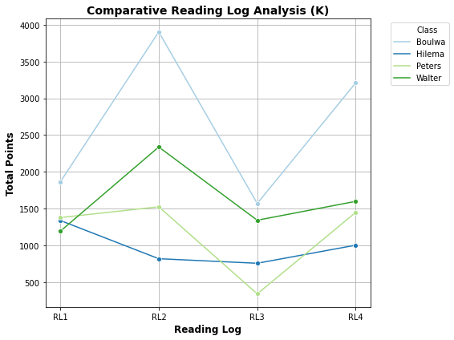

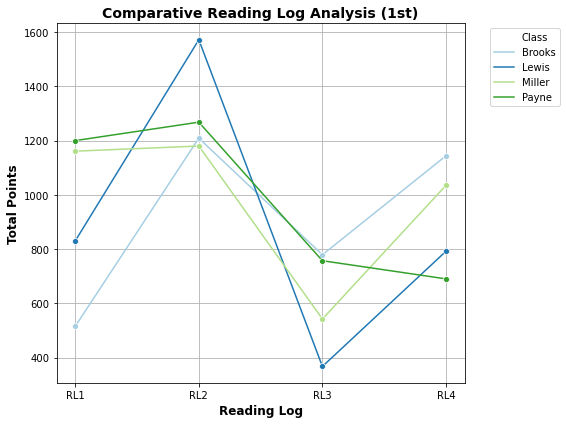

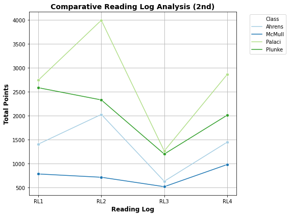

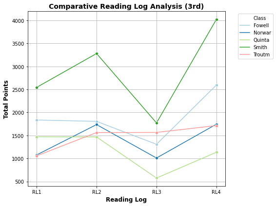

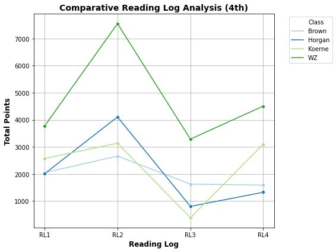

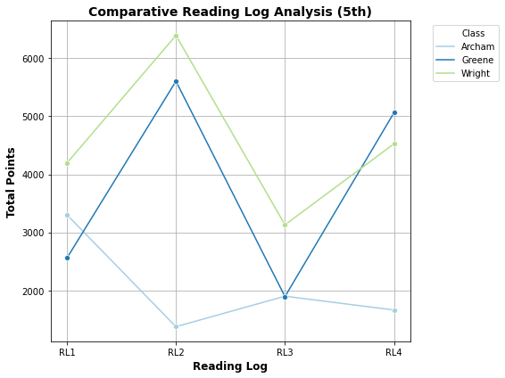

```python
for g, df in trends_dfs.items():
    df_long = df.melt(
        id_vars=["Class"],
        value_vars=["RL1","RL2","RL3","RL4"],
        var_name="RL",
        value_name="TotalPoints"
    )

    plt.figure(figsize=(8,6))

    # Dynamically generate a color palette matching the number of classes
    n_classes = df['Class'].nunique()
    colors = sns.color_palette("Paired", n_classes)

    sns.lineplot(
        data=df_long,
        x="RL",
        y="TotalPoints",
        hue="Class",
        marker="o",
        palette=colors
    )

    plt.title(f"Comparative Reading Log Analysis ({grade_names[g]})", fontsize=14, fontweight='bold')
    plt.xlabel("Reading Log", fontsize=12, fontweight='bold')
    plt.ylabel("Total Points", fontsize=12, fontweight='bold')
    plt.grid(True)
    plt.legend(bbox_to_anchor=(1.05,1), loc="upper left")
    plt.tight_layout()
    plt.show()
```

Back to top

## **Class Performance Distribution & Outliers**

**Objective:** Examine how student performance varies within and across classes, and identify outliers to highlight exceptional or struggling students.

**Key Takeaways:**

- Provides a clear picture of class and teacher-level performance variability.
- Helps administrators and teachers identify students needing support and recognize top performers.
- Combines average points and outlier detection to support data-driven decisions for instruction and intervention.

### Average Points Per Student Per Class

- Computes the mean total points per student for each class.
- Provides an overview of typical student performance and helps compare classes at a glance.
- Insight: Classes with higher averages indicate stronger overall performance, while lower averages may signal areas needing instructional support.
- Visual: Boxplots showing the distribution of average `TotalPoints` per `Student` across `Classes`.

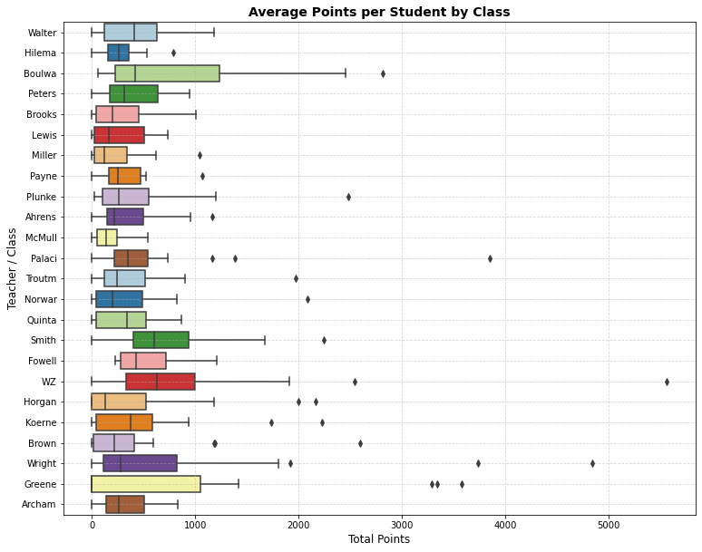

```python
df_avg = MMRC_df.groupby(['Grade','Teacher','Student'])['TotalPoints'].mean().reset_index()
df_avg = set_grade_order(df_avg)
plt.figure(figsize=(12.5,10))
sns.boxplot(data=df_avg, y='Teacher', x='TotalPoints', palette=sns.color_palette("Paired"))
plt.title("Average Points per Student by Class", fontsize=14, fontweight='bold')
plt.xlabel("Total Points", fontsize=12)
plt.ylabel("Teacher / Class", fontsize=12)
plt.grid(True, linestyle='--', alpha=0.5)
plt.show()
```

### Identify Outliers Using IQR

- Detects outliers using the Interquartile Range (IQR) method.

```python
Q1 = MMRC_df['TotalPoints'].quantile(0.25)
Q3 = MMRC_df['TotalPoints'].quantile(0.75)
IQR = Q3 - Q1
outliers = MMRC_df[(MMRC_df['TotalPoints'] < Q1 - 1.5*IQR) | (MMRC_df['TotalPoints'] > Q3 + 1.5*IQR)]
```

### Total Points Distribution & Outliers By Teacher

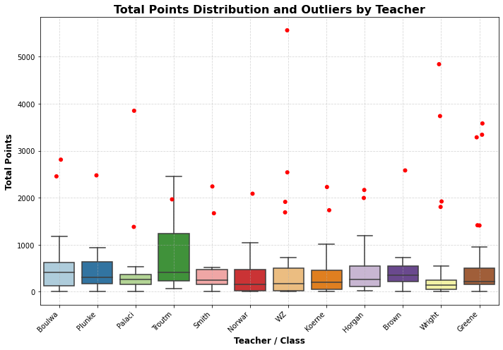

```python
# Boxplot per teacher with outliers
plt.figure(figsize=(10,7))
sns.boxplot(data=MMRC_df, x='Teacher', y='TotalPoints', palette=sns.color_palette("Paired"), showfliers=False)
sns.stripplot(data=outliers, x='Teacher', y='TotalPoints', color='red', size=6, jitter=True)
plt.title('Total Points Distribution and Outliers by Teacher', fontsize=16, fontweight='bold')
plt.xlabel('Teacher / Class', fontsize=12, fontweight='bold')
plt.ylabel('Total Points', fontsize=12, fontweight='bold')
plt.xticks(rotation=45, ha='right')
plt.grid(True, linestyle='--', alpha=0.5)
plt.tight_layout()
plt.show()
```

Back to top